# Lab 1: Installing Jupyter Notebook and Diving into ggplot

Derek Hansen (Credit to Yanxin Jin; all errors are my own)

# Lab 1 Overview

1. Organization
2. Icebreaker
3. Getting set up with R and Jupyter
4. Additional R and ggplot basics
5. Troubleshooting (if time permits)

### Office Hours

- Derek Hansen: M 9:00-10:30am
- Yanxin Jin: Tu 8:30-10:00am
- Jing Ouyang: Wed 12:00pm-1:30pm
- Brian Manzo: Th 9:00-10:30am

# Contact

- Homework and lecture question: Piazza
  - All GSIs and Prof. Tan can answer
  - Option to be anonymous to other students (but GSIs and Prof. Tan will see your name)
- For other concerns related to the course: dereklh@umich.edu
  - Please put [STATS 306] in your heading

# Lab

- About 1.5 hours (1:00pm - 2:20pm)
- All notes from this Lab will be available on Github: https://github.com/dereklhansen/stats306_lab
  - Jupyter notebook files (".ipynb") and PDFS (".pdf") available
  - You can use Binder to view and run Jupyter notebooks on Github: https://mybinder.org/v2/gh/dereklhansen/stats306_lab/master
  - But you'll need to download them to your own machine to save your edits
- Recordings will be uploaded to Canvas
- 10 minute break halfway through (if lecture will take the entire time)
- Please keep your mic muted unless actively speaking
- No webcams required unless we are doing an interactive activity

# Homework submission

- Write your homework in jupyter notebook and submit .ipynb file to the main course Canvas page (STATS 306 001)

## Icebreaker

- Name?
- Major?
- Year?
- Fun fact (e.g. what motivated you to take this course?)

## Getting set up with R and Jupyter

- I'm going to walk through an easy way to get up and running with R and Jupyter without the command line
- https://docs.anaconda.com/anaconda/navigator/tutorials/r-lang/

## Additional R and ggplot basics

Here we'll demonstrate another dataset: the diamonds dataset.

```r
suppressMessages(library(tidyverse))

head(diamonds)
```

A tibble: 6 × 10

| carat <dbl> | cut <ord> | color <ord> | clarity <ord> | depth <dbl> | table <dbl> | price <int> | x <dbl> | y <dbl> | z <dbl> |
| --- | --- | --- | --- | --- | --- | --- | --- | --- | --- |
| 0.23 | Ideal | E | SI2 | 61.5 | 55 | 326 | 3.95 | 3.98 | 2.43 |
| 0.21 | Premium | E | SI1 | 59.8 | 61 | 326 | 3.89 | 3.84 | 2.31 |
| 0.23 | Good | E | VS1 | 56.9 | 65 | 327 | 4.05 | 4.07 | 2.31 |
| 0.29 | Premium | I | VS2 | 62.4 | 58 | 334 | 4.20 | 4.23 | 2.63 |
| 0.31 | Good | J | SI2 | 63.3 | 58 | 335 | 4.34 | 4.35 | 2.75 |
| 0.24 | Very Good | J | VVS2 | 62.8 | 57 | 336 | 3.94 | 3.96 | 2.48 |

```r
summary(diamonds)
```

```
     carat               cut        color        clarity          depth
 Min.   :0.2000   Fair     : 1610   D: 6775   SI1    :13065   Min.   :43.00
 1st Qu.:0.4000   Good     : 4906   E: 9797   VS2    :12258   1st Qu.:61.00
 Median :0.7000   Very Good:12082   F: 9542   SI2    : 9194   Median :61.80
 Mean   :0.7979   Premium  :13791   G:11292   VS1    : 8171   Mean   :61.75
 3rd Qu.:1.0400   Ideal    :21551   H: 8304   VVS2   : 5066   3rd Qu.:62.50
 Max.   :5.0100                     I: 5422   VVS1   : 3655   Max.   :79.00
                                    J: 2808   (Other): 2531
     table           price             x                y
 Min.   :43.00   Min.   :  326   Min.   : 0.000   Min.   : 0.000
 1st Qu.:56.00   1st Qu.:  950   1st Qu.: 4.710   1st Qu.: 4.720
 Median :57.00   Median : 2401   Median : 5.700   Median : 5.710
 Mean   :57.46   Mean   : 3933   Mean   : 5.731   Mean   : 5.735
 3rd Qu.:59.00   3rd Qu.: 5324   3rd Qu.: 6.540   3rd Qu.: 6.540
 Max.   :95.00   Max.   :18823   Max.   :10.740   Max.   :58.900

       z
 Min.   : 0.000
 1st Qu.: 2.910
 Median : 3.530
 Mean   : 3.539
 3rd Qu.: 4.040
 Max.   :31.800
```

### R's built-in help

Just about everything in R is documented. Use the `help` function to open up a pop-up about the object in question.

```r
help(diamonds)
```

```r
?diamonds
```

- Here the help for the diamonds dataset says: "A dataset containing the prices and other attributes of almost 54,000 diamonds".
- It also describes the variables in each of the columns.

### Saving and loading R objects

- An important part of data analysis is saving your work so you can read it in later.
- The `saveRDS` function will save an object as a file
- The `readRDS` function will read a saved object from a file
- Use ".rds" or ".RDS" file extensions
- Note: "RDS" files can only be read by R!
- By default, saves in the current directory

```r
saveRDS(diamonds, "diamonds.rds")
diamonds2 <- readRDS("diamonds.rds")
diamonds2
```

A tibble: 53940 × 10

| carat <dbl> | cut <ord> | color <ord> | clarity <ord> | depth <dbl> | table <dbl> | price <int> | x <dbl> | y <dbl> | z <dbl> |
| --- | --- | --- | --- | --- | --- | --- | --- | --- | --- |
| 0.23 | Ideal | E | SI2 | 61.5 | 55 | 326 | 3.95 | 3.98 | 2.43 |
| 0.21 | Premium | E | SI1 | 59.8 | 61 | 326 | 3.89 | 3.84 | 2.31 |
| 0.23 | Good | E | VS1 | 56.9 | 65 | 327 | 4.05 | 4.07 | 2.31 |
| 0.29 | Premium | I | VS2 | 62.4 | 58 | 334 | 4.20 | 4.23 | 2.63 |
| 0.31 | Good | J | SI2 | 63.3 | 58 | 335 | 4.34 | 4.35 | 2.75 |
| 0.24 | Very Good | J | VVS2 | 62.8 | 57 | 336 | 3.94 | 3.96 | 2.48 |
| 0.24 | Very Good | I | VVS1 | 62.3 | 57 | 336 | 3.95 | 3.98 | 2.47 |
| 0.26 | Very Good | H | SI1 | 61.9 | 55 | 337 | 4.07 | 4.11 | 2.53 |
| 0.22 | Fair | E | VS2 | 65.1 | 61 | 337 | 3.87 | 3.78 | 2.49 |
| 0.23 | Very Good | H | VS1 | 59.4 | 61 | 338 | 4.00 | 4.05 | 2.39 |
| 0.30 | Good | J | SI1 | 64.0 | 55 | 339 | 4.25 | 4.28 | 2.73 |
| 0.23 | Ideal | J | VS1 | 62.8 | 56 | 340 | 3.93 | 3.90 | 2.46 |
| 0.22 | Premium | F | SI1 | 60.4 | 61 | 342 | 3.88 | 3.84 | 2.33 |
| 0.31 | Ideal | J | SI2 | 62.2 | 54 | 344 | 4.35 | 4.37 | 2.71 |
| 0.20 | Premium | E | SI2 | 60.2 | 62 | 345 | 3.79 | 3.75 | 2.27 |
| 0.32 | Premium | E | I1 | 60.9 | 58 | 345 | 4.38 | 4.42 | 2.68 |
| 0.30 | Ideal | I | SI2 | 62.0 | 54 | 348 | 4.31 | 4.34 | 2.68 |
| 0.30 | Good | J | SI1 | 63.4 | 54 | 351 | 4.23 | 4.29 | 2.70 |
| 0.30 | Good | J | SI1 | 63.8 | 56 | 351 | 4.23 | 4.26 | 2.71 |
| 0.30 | Very Good | J | SI1 | 62.7 | 59 | 351 | 4.21 | 4.27 | 2.66 |
| 0.30 | Good | I | SI2 | 63.3 | 56 | 351 | 4.26 | 4.30 | 2.71 |
| 0.23 | Very Good | E | VS2 | 63.8 | 55 | 352 | 3.85 | 3.92 | 2.48 |
| 0.23 | Very Good | H | VS1 | 61.0 | 57 | 353 | 3.94 | 3.96 | 2.41 |
| 0.31 | Very Good | J | SI1 | 59.4 | 62 | 353 | 4.39 | 4.43 | 2.62 |
| 0.31 | Very Good | J | SI1 | 58.1 | 62 | 353 | 4.44 | 4.47 | 2.59 |
| 0.23 | Very Good | G | VVS2 | 60.4 | 58 | 354 | 3.97 | 4.01 | 2.41 |
| 0.24 | Premium | I | VS1 | 62.5 | 57 | 355 | 3.97 | 3.94 | 2.47 |
| 0.30 | Very Good | J | VS2 | 62.2 | 57 | 357 | 4.28 | 4.30 | 2.67 |
| 0.23 | Very Good | D | VS2 | 60.5 | 61 | 357 | 3.96 | 3.97 | 2.40 |
| 0.23 | Very Good | F | VS1 | 60.9 | 57 | 357 | 3.96 | 3.99 | 2.42 |
| ⋮ | ⋮ | ⋮ | ⋮ | ⋮ | ⋮ | ⋮ | ⋮ | ⋮ | ⋮ |
| 0.70 | Premium | E | SI1 | 60.5 | 58 | 2753 | 5.74 | 5.77 | 3.48 |
| 0.57 | Premium | E | IF | 59.8 | 60 | 2753 | 5.43 | 5.38 | 3.23 |
| 0.61 | Premium | F | VVS1 | 61.8 | 59 | 2753 | 5.48 | 5.40 | 3.36 |
| 0.80 | Good | G | VS2 | 64.2 | 58 | 2753 | 5.84 | 5.81 | 3.74 |
| 0.84 | Good | I | VS1 | 63.7 | 59 | 2753 | 5.94 | 5.90 | 3.77 |
| 0.77 | Ideal | E | SI2 | 62.1 | 56 | 2753 | 5.84 | 5.86 | 3.63 |
| 0.74 | Good | D | SI1 | 63.1 | 59 | 2753 | 5.71 | 5.74 | 3.61 |
| 0.90 | Very Good | J | SI1 | 63.2 | 60 | 2753 | 6.12 | 6.09 | 3.86 |
| 0.76 | Premium | I | VS1 | 59.3 | 62 | 2753 | 5.93 | 5.85 | 3.49 |
| 0.76 | Ideal | I | VVS1 | 62.2 | 55 | 2753 | 5.89 | 5.87 | 3.66 |
| 0.70 | Very Good | E | VS2 | 62.4 | 60 | 2755 | 5.57 | 5.61 | 3.49 |
| 0.70 | Very Good | E | VS2 | 62.8 | 60 | 2755 | 5.59 | 5.65 | 3.53 |
| 0.70 | Very Good | D | VS1 | 63.1 | 59 | 2755 | 5.67 | 5.58 | 3.55 |
| 0.73 | Ideal | I | VS2 | 61.3 | 56 | 2756 | 5.80 | 5.84 | 3.57 |
| 0.73 | Ideal | I | VS2 | 61.6 | 55 | 2756 | 5.82 | 5.84 | 3.59 |
| 0.79 | Ideal | I | SI1 | 61.6 | 56 | 2756 | 5.95 | 5.97 | 3.67 |
| 0.71 | Ideal | E | SI1 | 61.9 | 56 | 2756 | 5.71 | 5.73 | 3.54 |
| 0.79 | Good | F | SI1 | 58.1 | 59 | 2756 | 6.06 | 6.13 | 3.54 |
| 0.79 | Premium | E | SI2 | 61.4 | 58 | 2756 | 6.03 | 5.96 | 3.68 |
| 0.71 | Ideal | G | VS1 | 61.4 | 56 | 2756 | 5.76 | 5.73 | 3.53 |
| 0.71 | Premium | E | SI1 | 60.5 | 55 | 2756 | 5.79 | 5.74 | 3.49 |
| 0.71 | Premium | F | SI1 | 59.8 | 62 | 2756 | 5.74 | 5.73 | 3.43 |
| 0.70 | Very Good | E | VS2 | 60.5 | 59 | 2757 | 5.71 | 5.76 | 3.47 |
| 0.70 | Very Good | E | VS2 | 61.2 | 59 | 2757 | 5.69 | 5.72 | 3.49 |
| 0.72 | Premium | D | SI1 | 62.7 | 59 | 2757 | 5.69 | 5.73 | 3.58 |
| 0.72 | Ideal | D | SI1 | 60.8 | 57 | 2757 | 5.75 | 5.76 | 3.50 |
| 0.72 | Good | D | SI1 | 63.1 | 55 | 2757 | 5.69 | 5.75 | 3.61 |
| 0.70 | Very Good | D | SI1 | 62.8 | 60 | 2757 | 5.66 | 5.68 | 3.56 |
| 0.86 | Premium | H | SI2 | 61.0 | 58 | 2757 | 6.15 | 6.12 | 3.74 |
| 0.75 | Ideal | D | SI2 | 62.2 | 55 | 2757 | 5.83 | 5.87 | 3.64 |

- More useful functions from the "readr" package (part of the tidyverse) are `read_csv` and `write_csv`
- These read and write "Comma Separated Value" files, which are text files that can be read as spreadsheets into programs such as Excel
- A lot of datasets come in CSV format
- Pretty much all data analysis programs support CSV (R, Python, SAS, Stata, Excel, etc)
- You can specify the variable type of each column, or R will guess automatically

```r
write_csv(diamonds, "diamonds.csv")
diamonds3 <- read_csv("diamonds.csv")
```

Many more file formats that R can read and write to:

- `read_tsv`, `read_delim` for text files with different text seperators
- `haven` package for reading to/from Stata, SAS, SDSS
- `readxl` package for reading to/from Excel
  - Generally better to just use CSV with Excel possible!

# Creating the first plot

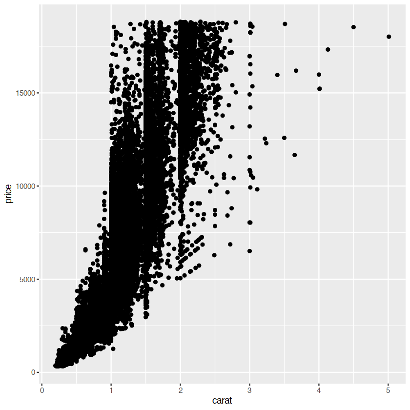

```r
ggplot(data=diamonds) +
    geom_point(mapping = aes(x = carat, y = price))
```

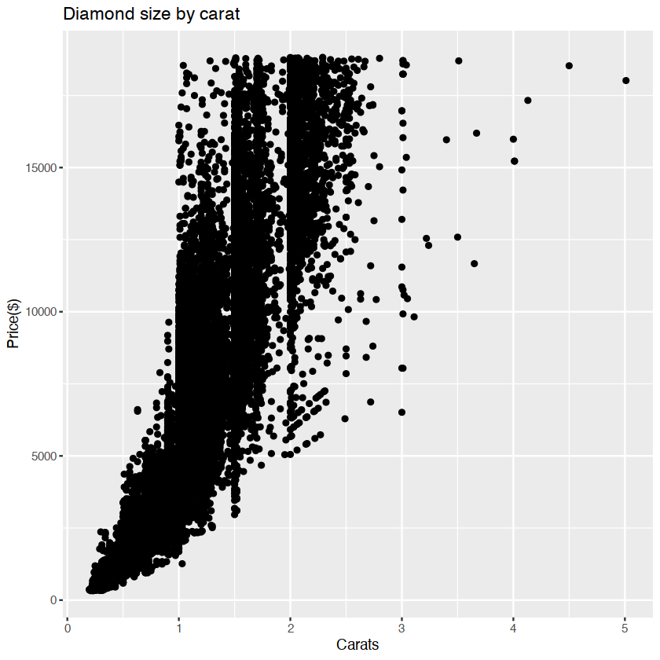

```r
ggplot(data=diamonds) +
    geom_point(mapping = aes(x = carat, y = price)) +
    labs(x = 'Carats', y = 'Price($)') +
    ggtitle('Diamond size by carat')
```

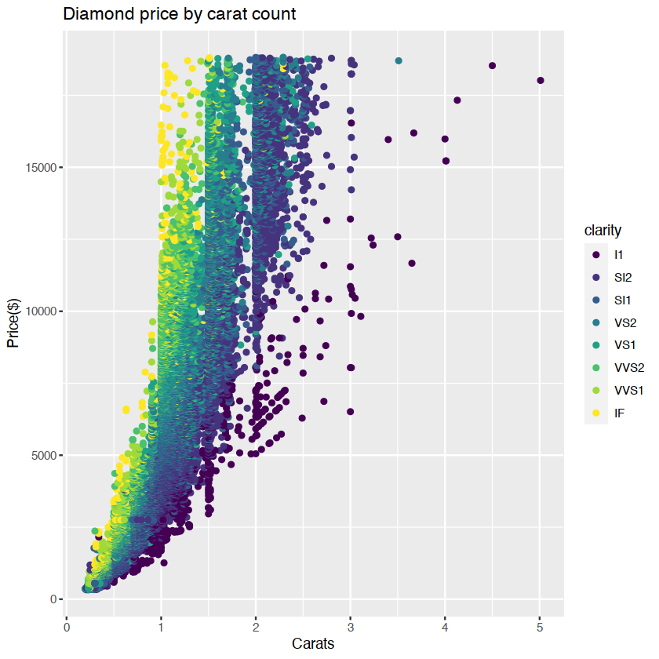

```r
ggplot(data = diamonds) +
    geom_point(mapping = aes(x = carat, y = price, color = clarity)) +
    labs(x = 'Carats', y = 'Price($)') +
    ggtitle('Diamond price by carat count')
```

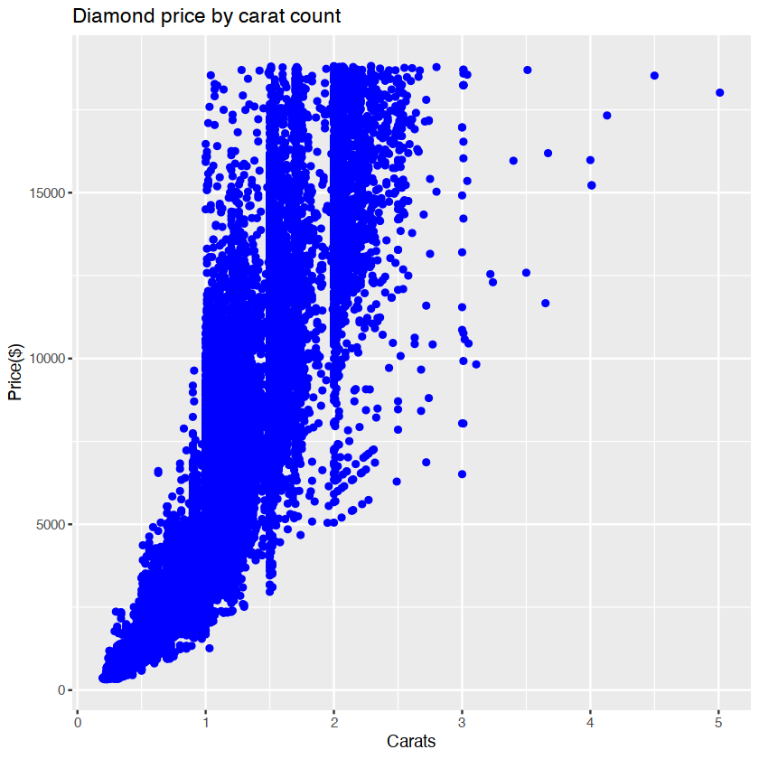

```r
ggplot(data = diamonds) +
    geom_point(mapping = aes(x = carat, y = price), color = 'blue') +
    labs(x = 'Carats', y = 'Price($)') +
    ggtitle('Diamond price by carat count')
```

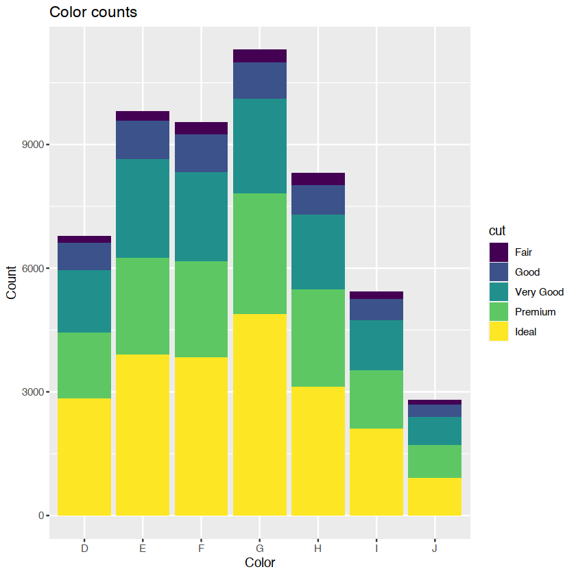

```r
ggplot(data = diamonds) +
    # geom_point(mapping = aes(x = carat, y = price, color = clarity)) +
    geom_bar(mapping = aes(x = color, fill = cut)) +
    labs(x = 'Color', y = 'Count') +
    ggtitle('Color counts')
```

## Package documentation

```
?head
?tail
?geom_bar

You can always google the package documentations as well. For example, can you find the documentation page for rnorm?
```

## Exercise

```
1. What is the default value of the mean and standard deviation used by the ``rnorm'' function in R to generate a value from a normal distribution?
2. Create a boxplot of `price' grouped by the levels in the `cut' variable. (see Jupyter notebook for snippets for a hint)
```